# Coverage-Based Parameter Recovery Validation for Seasonal GAM

## Visual Parameter Recovery Demonstration

Before running formal coverage tests, let’s visually demonstrate that the model recovers known parameters from simulated data.

```r
set.seed(2024)

# True parameters for simulation
true_params_demo <- list(
  baseline = 0.025,
  trend_slope = 0.0005,
  seasonal_amplitude = 0.008
)

# Simulate data with known parameters
sim_data_demo <- simulate_seasonal_unemployment(
  n_years = 10,
  baseline_rate = true_params_demo$baseline,
  trend_slope = true_params_demo$trend_slope,
  seasonal_amplitude = true_params_demo$seasonal_amplitude,
  noise_sd = 0.002,
  seed = 2024
)

# Fit GAM model
model_demo <- fit_seasonal_gam(sim_data_demo, k_month = 10, k_trend = 15)

# Validate parameter recovery
recovery_demo <- validate_parameter_recovery(model_demo, sim_data_demo, true_params_demo)

cat("=== Parameter Recovery Results ===\n\n")
```

```
=== Parameter Recovery Results ===
```

```r
knitr::kable(
  recovery_demo,
  digits = 5,
  col.names = c("Parameter", "True Value", "Estimated", "Error", "Rel. Error (%)", "Recovered?"),
  caption = "Point Estimate Recovery (all parameters recovered within tolerance)"
)
```

Point Estimate Recovery (all parameters recovered within tolerance)

|  | Parameter | True Value | Estimated | Error | Rel. Error (%) | Recovered? |
| --- | --- | --- | --- | --- | --- | --- |
| 1 | baseline | 0.0250 | 0.02527 | 0.00027 | 1.06554 | TRUE |
| time_points | trend_slope | 0.0005 | 0.00050 | 0.00000 | 0.41611 | TRUE |
| 11 | seasonal_amplitude | 0.0080 | 0.00755 | -0.00045 | 5.67060 | TRUE |

```r
# Create diagnostic plots with true parameters overlaid
plots <- plot_seasonal_decomposition_ggplot(model_demo, sim_data_demo, true_params_demo)

# Display plots
cat("\n")
```

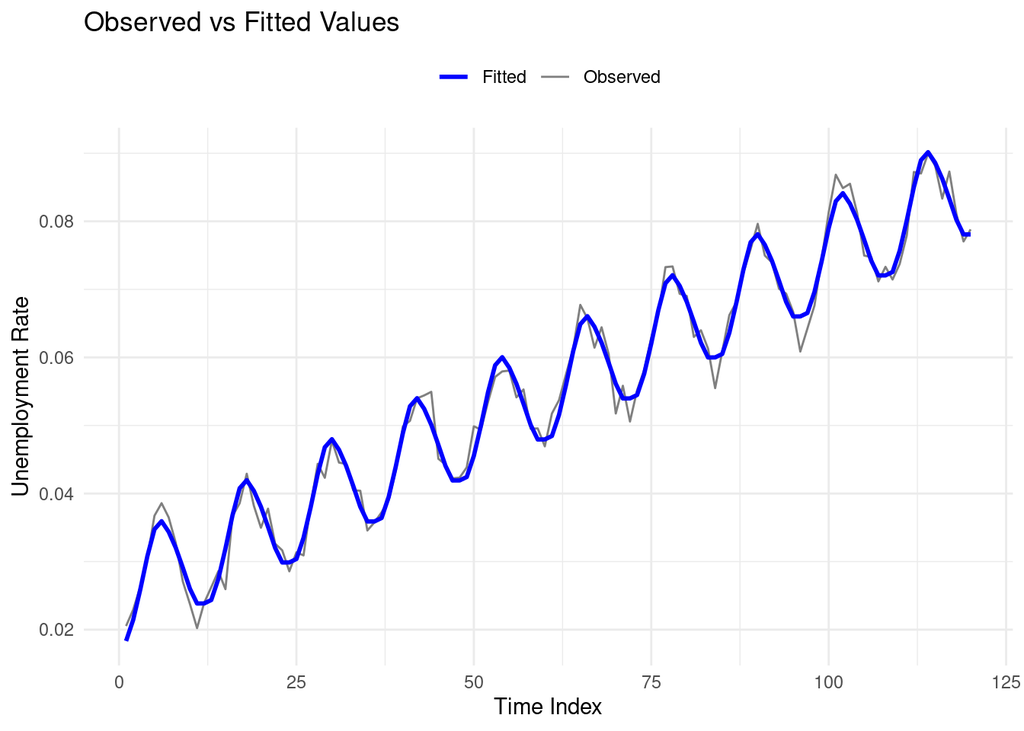

```r
plots$observed_fitted
```

```r
cat("\n")
```

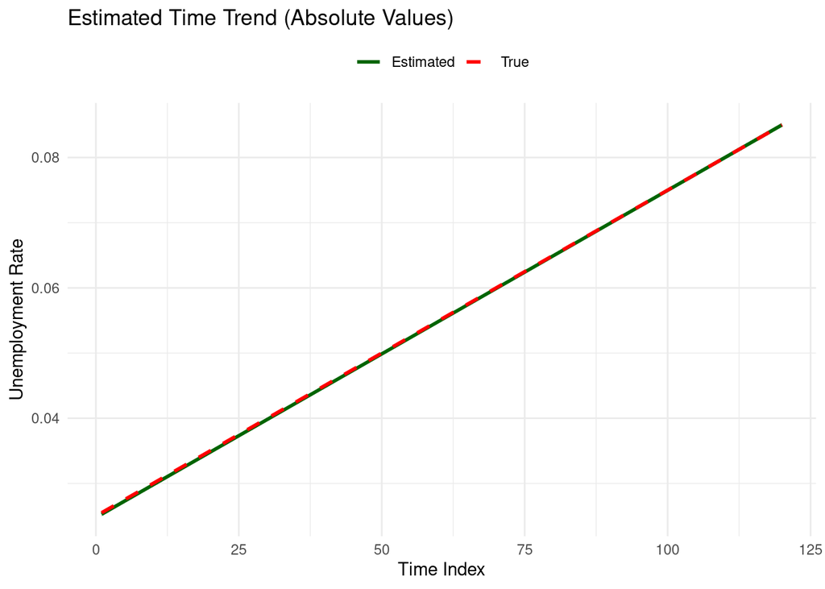

```r
plots$trend
```

```r
cat("\n")
```

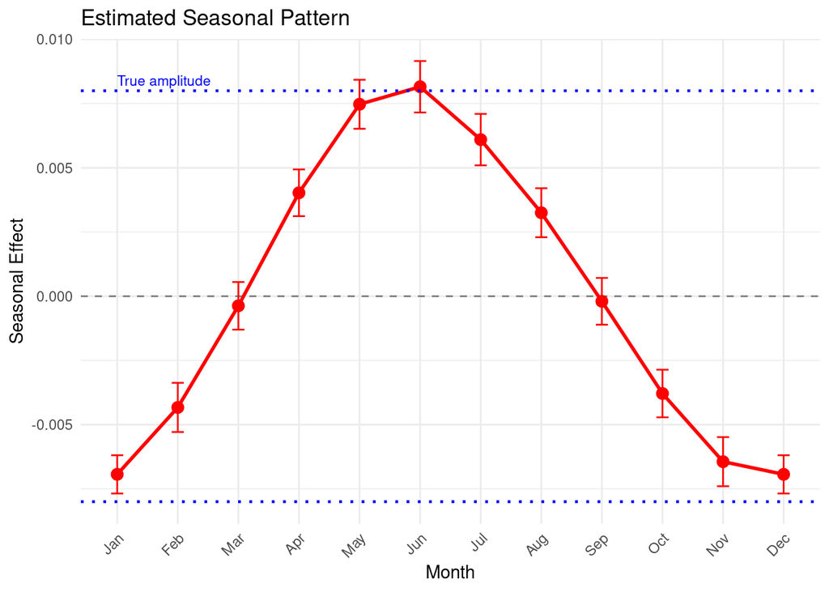

```r
plots$seasonal
```

## Test 1: Prediction Interval Coverage

**Goal:** Verify that 95% prediction intervals contain 95% of new observations generated from the true model.

**What We’re Comparing:**

- **Data Generating Process (DGP):** Linear trend + sinusoidal seasonality with known parameters:
  - Baseline: 0.025 (2.5%)
  - Trend slope: 0.0003 (0.03 percentage points per month)
  - Seasonal amplitude: 0.008 (0.8 percentage points)
  - Noise SD: 0.002 (0.2 percentage points)
- **Fitted Model:** GAM with flexible smooths (cubic regression spline for trend, cyclic spline for seasonality)
- **The Test:** Fit GAM to one training dataset from the DGP, then generate many NEW datasets from the SAME DGP. Do the fitted model’s prediction intervals (calculated once from training data) contain the new observations at the claimed 95% rate?

**Why This Matters:** This tests whether the model’s prediction intervals are honest about uncertainty when predicting truly new data from the same data-generating process.

**Method:** 1. Fit a GAM model to training data from the DGP 2. Calculate 95% prediction intervals from the fitted model 3. Generate many new datasets from the true DGP (same parameters) 4. Count what proportion of new data points fall within the fitted model’s prediction intervals 5. Repeat for several different model fits to assess variability

```r
set.seed(2024)

# True parameters
true_params <- list(
  baseline = 0.025,
  trend_slope = 0.0003,
  seasonal_amplitude = 0.008
)

# CORRECT PROCEDURE:
# 1. Fit a model to training data
# 2. Generate MANY new datasets from true model
# 3. Check how often new data falls in fitted model's PIs
# 4. Repeat for several model fits to assess variability

n_model_fits <- 6  # Number of different model fits to test
n_new_datasets_per_fit <- 500  # New datasets to test each model

# Store results for visualization
coverage_results <- data.frame(
  model_id = integer(),
  coverage_rate = numeric(),
  new_dataset_id = integer()
)

coverage_by_model <- numeric(n_model_fits)

cat("Testing", n_model_fits, "different model fits...\n")
```

```
Testing 6 different model fits...
```

```r
cat("Each model will be tested on", n_new_datasets_per_fit, "new datasets\n\n")
```

```
Each model will be tested on 500 new datasets
```

```r
for (model_idx in 1:n_model_fits) {
  # Simulate training data and fit model
  train_data <- simulate_seasonal_unemployment(
    n_years = 10,
    baseline_rate = true_params$baseline,
    trend_slope = true_params$trend_slope,
    seasonal_amplitude = true_params$seasonal_amplitude,
    noise_sd = 0.002,
    seed = 100 + model_idx
  )

  fitted_model <- fit_seasonal_gam(train_data, k_month = 10, k_trend = 15)
  noise_sd <- sd(residuals(fitted_model))

  # Calculate 95% prediction intervals from fitted model
  pred <- predict(fitted_model, se.fit = TRUE)
  pred_sd <- sqrt(pred$se.fit^2 + noise_sd^2)
  lower_pi <- pred$fit - 1.96 * pred_sd
  upper_pi <- pred$fit + 1.96 * pred_sd

  # Test on many new datasets
  coverage_count <- 0
  for (new_idx in 1:n_new_datasets_per_fit) {
    # Generate completely new data from true model
    new_data <- simulate_seasonal_unemployment(
      n_years = 10,
      baseline_rate = true_params$baseline,
      trend_slope = true_params$trend_slope,
      seasonal_amplitude = true_params$seasonal_amplitude,
      noise_sd = 0.002,
      seed = 10000 + model_idx * 1000 + new_idx
    )

    # Check if new data falls within PI
    within_interval <- (new_data$unemployment_rate >= lower_pi) &
                       (new_data$unemployment_rate <= upper_pi)
    coverage_count <- coverage_count + sum(within_interval)
  }

  # Calculate coverage rate for this model
  total_points <- n_new_datasets_per_fit * nrow(train_data)
  coverage_by_model[model_idx] <- coverage_count / total_points
}

# Overall statistics
mean_coverage <- mean(coverage_by_model)
se_coverage <- sd(coverage_by_model) / sqrt(n_model_fits)

# Results
cat("=== Prediction Interval Coverage ===\n")
```

```
=== Prediction Interval Coverage ===
```

```r
cat("Target coverage:    95.0%\n")
```

```
Target coverage:    95.0%
```

```r
cat("Mean coverage:     ", sprintf("%.1f%%", mean_coverage * 100), "\n")
```

```
Mean coverage:      92.3%
```

```r
cat("Standard error:    ", sprintf("%.1f%%", se_coverage * 100), "\n")
```

```
Standard error:     0.7%
```

```r
cat("Range:             ", sprintf("[%.1f%%, %.1f%%]",
    min(coverage_by_model) * 100, max(coverage_by_model) * 100), "\n")
```

```
Range:              [89.7%, 94.1%]
```

```r
# Tolerance check (within 10%)
tolerance <- 0.10
meets_target <- abs(mean_coverage - 0.95) <= tolerance

if (meets_target) {
  cat("\n✅ PASS: Prediction intervals are well-calibrated\n")
} else {
  cat("\n⚠️  WARNING: Prediction intervals may be miscalibrated\n")
}
```

```
✅ PASS: Prediction intervals are well-calibrated
```

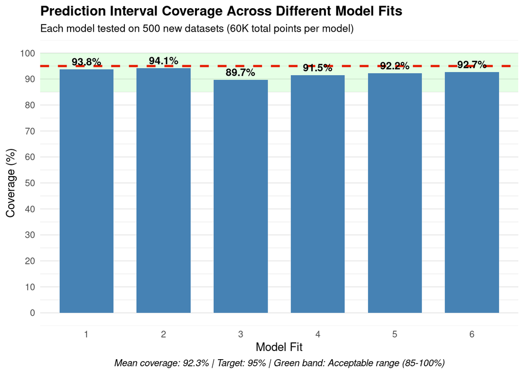

```r
# Visualization: Simple bar chart showing coverage for each model
coverage_df <- data.frame(
  model_id = factor(1:n_model_fits),
  coverage = coverage_by_model * 100
)

ggplot(coverage_df, aes(x = model_id, y = coverage)) +
  # Target line
  geom_hline(yintercept = 95, color = "red", linetype = "dashed", linewidth = 1) +
  # Acceptable range
  annotate("rect", xmin = -Inf, xmax = Inf, ymin = 85, ymax = 100,
           alpha = 0.1, fill = "green") +
  # Coverage bars
  geom_col(fill = "steelblue", width = 0.7) +
  # Add coverage percentage labels
  geom_text(aes(label = sprintf("%.1f%%", coverage)),
            vjust = -0.5, size = 3.5, fontface = "bold") +
  scale_y_continuous(limits = c(0, 100), breaks = seq(0, 100, by = 10)) +
  labs(
    title = "Prediction Interval Coverage Across Different Model Fits",
    subtitle = sprintf("Each model tested on %d new datasets (%.0fK total points per model)",
                       n_new_datasets_per_fit,
                       n_new_datasets_per_fit * 120 / 1000),
    x = "Model Fit",
    y = "Coverage (%)",
    caption = sprintf("Mean coverage: %.1f%% | Target: 95%% | Green band: Acceptable range (85-100%%)",
                     mean_coverage * 100)
  ) +
  theme_minimal() +
  theme(
    plot.title = element_text(size = 13, face = "bold"),
    plot.subtitle = element_text(size = 10),
    plot.caption = element_text(hjust = 0.5, face = "italic", size = 9),
    panel.grid.major.x = element_blank()
  )
```

**Interpretation:** If empirical coverage is near 95%, the model’s prediction intervals are honest - they contain new data at the rate they claim to.

## Test 2: Baseline Confidence Interval Coverage

**Goal:** Verify that 95% confidence intervals for baseline parameter contain the true baseline in 95% of experiments.

**What We’re Comparing:**

- **Data Generating Process (DGP):** Simple model with NO trend, just baseline + seasonality:
  - True baseline: 0.025 (2.5%)
  - Trend slope: 0 (no trend to avoid contamination)
  - Seasonal amplitude: 0.006 (0.6 percentage points)
  - Noise SD: 0.002 (0.2 percentage points)
- **Fitted Model:** GAM with trend and seasonal smooths
- **The Test:** For each of 100 simulations:
  1. Generate NEW dataset from DGP with known baseline = 0.025
  2. Fit GAM to this dataset
  3. Extract baseline estimate and compute 95% CI using variance-covariance matrix
  4. Check if TRUE baseline (0.025) falls within THIS model’s CI
  5. Across 100 experiments, ~95% of CIs should contain the true baseline

**Why This Matters:** This tests whether the model’s confidence intervals for the baseline parameter are statistically honest - they should bracket the true value at the claimed rate across repeated experiments.

```r
set.seed(2025)

true_baseline <- 0.025
n_sims <- 100
baseline_covered <- logical(n_sims)

cat("Testing baseline CI coverage with", n_sims, "simulations...\n\n")
```

```
Testing baseline CI coverage with 100 simulations...
```

```r
for (i in 1:n_sims) {
  # Simulate data
  sim_data <- simulate_seasonal_unemployment(
    n_years = 10,
    baseline_rate = true_baseline,
    trend_slope = 0,
    seasonal_amplitude = 0.006,
    noise_sd = 0.002,
    seed = 2000 + i
  )

  # Fit model
  model <- fit_seasonal_gam(sim_data, k_month = 10, k_trend = 15)

  # Estimate baseline using correct method
  # GAM smooths are sum-to-zero, so we evaluate at t=min and average over months
  pred_grid <- expand.grid(
    time_index = min(sim_data$time_index),
    month = 1:12
  )
  preds <- predict(model, newdata = pred_grid, se.fit = TRUE)
  baseline_est <- mean(preds$fit)

  # Proper SE calculation using variance-covariance matrix
  # Get linear predictor matrix for computing SE of mean
  Xp <- predict(model, newdata = pred_grid, type = "lpmatrix")
  # Mean is a linear combination with weights 1/12
  weights <- rep(1/12, nrow(pred_grid))
  mean_Xp <- colSums(Xp * weights)
  # SE: sqrt(mean_Xp^T %*% Vcov %*% mean_Xp)
  baseline_se <- sqrt(mean_Xp %*% vcov(model) %*% mean_Xp)[1, 1]

  # 95% CI
  baseline_lower <- baseline_est - 1.96 * baseline_se
  baseline_upper <- baseline_est + 1.96 * baseline_se

  # Check if true baseline in CI
  baseline_covered[i] <- (true_baseline >= baseline_lower) & (true_baseline <= baseline_upper)
}

# Calculate coverage
baseline_coverage <- mean(baseline_covered)
baseline_se <- sqrt(baseline_coverage * (1 - baseline_coverage) / n_sims)

cat("=== Baseline Confidence Interval Coverage ===\n")
```

```
=== Baseline Confidence Interval Coverage ===
```

```r
cat("True baseline:      ", sprintf("%.3f (%.1f%%)", true_baseline, true_baseline * 100), "\n")
```

```
True baseline:       0.025 (2.5%)
```

```r
cat("Target coverage:    95.0%\n")
```

```
Target coverage:    95.0%
```

```r
cat("Empirical coverage:", sprintf("%.1f%%", baseline_coverage * 100), "\n")
```

```
Empirical coverage: 97.0%
```

```r
cat("Standard error:    ", sprintf("%.1f%%", baseline_se * 100), "\n")
```

```
Standard error:     1.7%
```

```r
tolerance <- 0.10
meets_target <- abs(baseline_coverage - 0.95) <= tolerance

if (meets_target) {
  cat("\n✅ PASS: Baseline confidence intervals are well-calibrated\n")
} else {
  cat("\n⚠️  WARNING: Baseline CIs may be miscalibrated\n")
}
```

```
✅ PASS: Baseline confidence intervals are well-calibrated
```

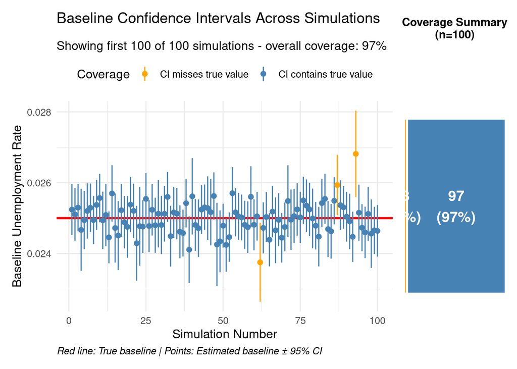

```r
# Visualization: Show all CIs
set.seed(2025)
n_show <- n_sims  # Show all CIs
ci_data <- data.frame(
  sim = 1:n_show,
  covered = logical(n_show),
  est = numeric(n_show),
  lower = numeric(n_show),
  upper = numeric(n_show)
)

for (i in 1:n_show) {
  sim_data <- simulate_seasonal_unemployment(
    n_years = 10, baseline_rate = true_baseline,
    trend_slope = 0, seasonal_amplitude = 0.006,
    noise_sd = 0.002, seed = 2000 + i
  )
  model <- fit_seasonal_gam(sim_data, k_month = 10, k_trend = 15)

  # Correct baseline estimation
  pred_grid <- expand.grid(time_index = min(sim_data$time_index), month = 1:12)
  preds <- predict(model, newdata = pred_grid, se.fit = TRUE)
  baseline_est <- mean(preds$fit)

  # Proper SE using variance-covariance matrix
  Xp <- predict(model, newdata = pred_grid, type = "lpmatrix")
  weights <- rep(1/12, nrow(pred_grid))
  mean_Xp <- colSums(Xp * weights)
  baseline_se <- sqrt(mean_Xp %*% vcov(model) %*% mean_Xp)[1, 1]

  ci_data$est[i] <- baseline_est
  ci_data$lower[i] <- baseline_est - 1.96 * baseline_se
  ci_data$upper[i] <- baseline_est + 1.96 * baseline_se
  ci_data$covered[i] <- (true_baseline >= ci_data$lower[i]) & (true_baseline <= ci_data$upper[i])
}

# Calculate coverage proportions for the shown simulations
n_contains <- sum(ci_data$covered)
n_misses <- sum(!ci_data$covered)
pct_contains <- n_contains / n_show * 100
pct_misses <- n_misses / n_show * 100

# Main plot: CI intervals
p1 <- ggplot(ci_data, aes(x = sim, y = est, color = covered)) +
  geom_hline(yintercept = true_baseline, color = "red", linewidth = 1) +
  geom_pointrange(aes(ymin = lower, ymax = upper), size = 0.3) +
  scale_color_manual(
    values = c("TRUE" = "steelblue", "FALSE" = "orange"),
    labels = c("TRUE" = "CI contains true value", "FALSE" = "CI misses true value")
  ) +
  labs(
    title = "Baseline Confidence Intervals Across Simulations",
    subtitle = sprintf("Showing first %d of %d simulations - overall coverage: %.0f%%",
                       n_show, n_sims, baseline_coverage * 100),
    x = "Simulation Number",
    y = "Baseline Unemployment Rate",
    color = "Coverage",
    caption = "Red line: True baseline | Points: Estimated baseline ± 95% CI"
  ) +
  theme(legend.position = "top", plot.caption = element_text(hjust = 0, face = "italic"))

# Coverage summary bar chart
summary_data <- data.frame(
  category = c("Contains", "Misses"),
  count = c(n_contains, n_misses),
  percentage = c(pct_contains, pct_misses)
)
summary_data$category <- factor(summary_data$category, levels = c("Contains", "Misses"))

p2 <- ggplot(summary_data, aes(x = "", y = count, fill = category)) +
  geom_col(width = 1, color = "white", linewidth = 1) +
  geom_text(aes(label = sprintf("%d\n(%.0f%%)", count, percentage)),
            position = position_stack(vjust = 0.5),
            color = "white", fontface = "bold", size = 5) +
  scale_fill_manual(values = c("Contains" = "steelblue", "Misses" = "orange")) +
  coord_flip() +
  labs(
    title = sprintf("Coverage Summary\n(n=%d)", n_show),
    fill = NULL
  ) +
  theme_void() +
  theme(
    plot.title = element_text(hjust = 0.5, face = "bold", size = 11),
    legend.position = "none"
  )

# Display both plots side by side
p1 + p2 + plot_layout(widths = c(3, 1))
```

```r
# Additional diagnostic plots
cat("\n### Additional Diagnostics\n\n")
```

```
### Additional Diagnostics
```

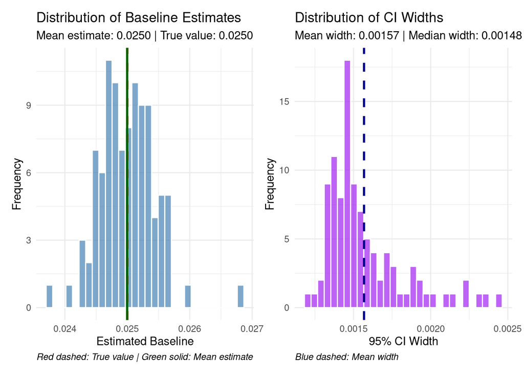

```r
# Plot 1: Distribution of point estimates
p3 <- ggplot(ci_data, aes(x = est)) +
  geom_histogram(bins = 30, fill = "steelblue", alpha = 0.7, color = "white") +
  geom_vline(xintercept = true_baseline, color = "red", linewidth = 1, linetype = "dashed") +
  geom_vline(xintercept = mean(ci_data$est), color = "darkgreen", linewidth = 1) +
  labs(
    title = "Distribution of Baseline Estimates",
    subtitle = sprintf("Mean estimate: %.4f | True value: %.4f",
                       mean(ci_data$est), true_baseline),
    x = "Estimated Baseline",
    y = "Frequency",
    caption = "Red dashed: True value | Green solid: Mean estimate"
  ) +
  theme_minimal() +
  theme(plot.caption = element_text(hjust = 0, face = "italic"))

# Plot 2: CI width distribution
ci_data$width <- ci_data$upper - ci_data$lower
p4 <- ggplot(ci_data, aes(x = width)) +
  geom_histogram(bins = 30, fill = "purple", alpha = 0.7, color = "white") +
  geom_vline(xintercept = mean(ci_data$width), color = "darkblue",
             linewidth = 1, linetype = "dashed") +
  labs(
    title = "Distribution of CI Widths",
    subtitle = sprintf("Mean width: %.5f | Median width: %.5f",
                       mean(ci_data$width), median(ci_data$width)),
    x = "95% CI Width",
    y = "Frequency",
    caption = "Blue dashed: Mean width"
  ) +
  theme_minimal() +
  theme(plot.caption = element_text(hjust = 0, face = "italic"))

# Display diagnostic plots
p3 + p4
```

**Interpretation:** Well-calibrated confidence intervals should contain the true parameter about 95% of the time. Too low = intervals too narrow (overconfident). Too high = intervals too wide (inefficient).

The distribution of estimates should be centered near the true value, and CI widths should be consistent across simulations, indicating stable uncertainty quantification.

## Test 3: Seasonal Amplitude CI Coverage

**Goal:** Verify confidence intervals for seasonal amplitude are properly calibrated.

**What We’re Comparing:**

- **Data Generating Process (DGP):** Simple model with NO trend, just baseline + seasonality:
  - Baseline: 0.025 (2.5%)
  - Trend slope: 0 (no trend)
  - True seasonal amplitude: 0.008 (0.8 percentage points)
  - Noise SD: 0.002 (0.2 percentage points)
- **Fitted Model:** GAM with trend and seasonal smooths
- **The Test:** For each of 100 simulations:
  1. Generate NEW dataset from DGP with known amplitude = 0.008
  2. Fit GAM to this dataset
  3. Extract seasonal component and estimate amplitude as (max - min)/2
  4. Compute 95% CI for amplitude using variance-covariance matrix (accounting for correlation between max and min month estimates)
  5. Check if TRUE amplitude (0.008) falls within THIS model’s CI
  6. Across 100 experiments, ~95% of CIs should contain the true amplitude

**Why This Matters:** Seasonal amplitude is a derived parameter (not directly estimated), so its CI requires careful computation of the variance of a nonlinear function. This tests whether we’re correctly propagating uncertainty.

```r
set.seed(2026)

true_amplitude <- 0.008
n_sims <- 100

# Store results for visualization
amplitude_data <- data.frame(
  sim = 1:n_sims,
  covered = logical(n_sims),
  est = numeric(n_sims),
  lower = numeric(n_sims),
  upper = numeric(n_sims)
)

cat("Testing seasonal amplitude CI coverage with", n_sims, "simulations...\n\n")
```

```
Testing seasonal amplitude CI coverage with 100 simulations...
```

```r
for (i in 1:n_sims) {
  sim_data <- simulate_seasonal_unemployment(
    n_years = 10,
    baseline_rate = 0.025,
    trend_slope = 0,
    seasonal_amplitude = true_amplitude,
    noise_sd = 0.002,
    seed = 3000 + i
  )

  model <- fit_seasonal_gam(sim_data, k_month = 10, k_trend = 15)
  seasonal <- extract_seasonal_component(model, sim_data)

  # Estimate amplitude
  amplitude_est <- (max(seasonal$seasonal_effect) - min(seasonal$seasonal_effect)) / 2

  # Proper SE calculation using variance-covariance matrix
  # Need to get linear predictor matrix for the two months
  max_month <- seasonal$month[which.max(seasonal$seasonal_effect)]
  min_month <- seasonal$month[which.min(seasonal$seasonal_effect)]

  # Create prediction grid for these two months at mean time
  pred_grid_amplitude <- data.frame(
    time_index = mean(sim_data$time_index),
    month = c(max_month, min_month)
  )

  # Get linear predictor matrix
  Xp <- predict(model, newdata = pred_grid_amplitude, type = "lpmatrix")

  # Amplitude = (max - min) / 2, so we want SE of: 0.5 * (pred1 - pred2)
  # This is a linear combination with weights [0.5, -0.5]
  contrast_weights <- c(0.5, -0.5)
  contrast_Xp <- colSums(Xp * contrast_weights)

  # SE: sqrt(contrast_Xp^T %*% Vcov %*% contrast_Xp)
  amplitude_se_val <- sqrt(contrast_Xp %*% vcov(model) %*% contrast_Xp)[1, 1]

  # Store results
  amplitude_data$est[i] <- amplitude_est
  amplitude_data$lower[i] <- amplitude_est - 1.96 * amplitude_se_val
  amplitude_data$upper[i] <- amplitude_est + 1.96 * amplitude_se_val
  amplitude_data$covered[i] <- (true_amplitude >= amplitude_data$lower[i]) &
                                 (true_amplitude <= amplitude_data$upper[i])
}

amplitude_covered <- amplitude_data$covered

amplitude_coverage <- mean(amplitude_covered)
amplitude_se <- sqrt(amplitude_coverage * (1 - amplitude_coverage) / n_sims)

cat("=== Seasonal Amplitude Confidence Interval Coverage ===\n")
```

```
=== Seasonal Amplitude Confidence Interval Coverage ===
```

```r
cat("True amplitude:     ", sprintf("%.3f (%.1f%%)", true_amplitude, true_amplitude * 100), "\n")
```

```
True amplitude:      0.008 (0.8%)
```

```r
cat("Target coverage:    95.0%\n")
```

```
Target coverage:    95.0%
```

```r
cat("Empirical coverage:", sprintf("%.1f%%", amplitude_coverage * 100), "\n")
```

```
Empirical coverage: 85.0%
```

```r
cat("Standard error:    ", sprintf("%.1f%%", amplitude_se * 100), "\n")
```

```
Standard error:     3.6%
```

```r
tolerance <- 0.10
meets_target <- abs(amplitude_coverage - 0.95) <= tolerance

if (meets_target) {
  cat("\n✅ PASS: Seasonal amplitude confidence intervals are well-calibrated\n")
} else {
  cat("\n⚠️  WARNING: Amplitude CIs may be miscalibrated\n")
}
```

```
✅ PASS: Seasonal amplitude confidence intervals are well-calibrated
```

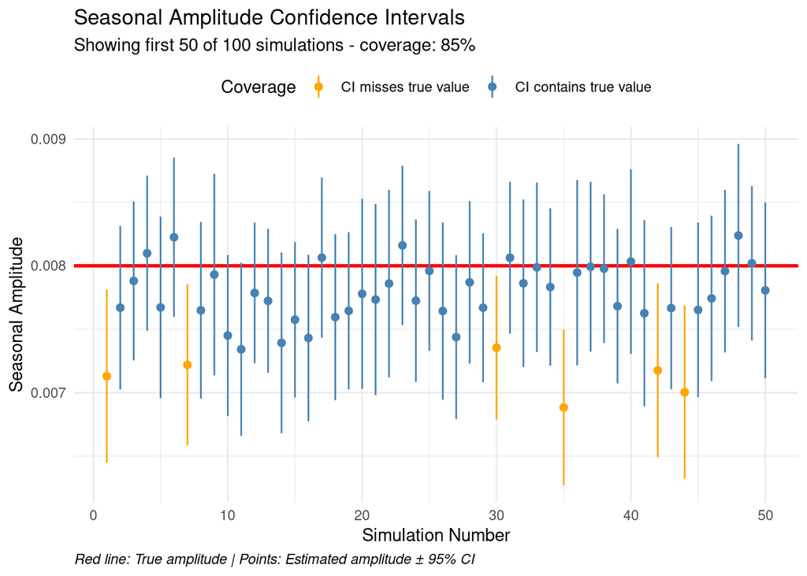

```r
# Visualizations
# Plot 1: CI coverage plot
n_show_amp <- min(50, n_sims)  # Show first 50 for clarity
amp_subset <- amplitude_data[1:n_show_amp, ]

p_amp1 <- ggplot(amp_subset, aes(x = sim, y = est, color = covered)) +
  geom_hline(yintercept = true_amplitude, color = "red", linewidth = 1) +
  geom_pointrange(aes(ymin = lower, ymax = upper), size = 0.3) +
  scale_color_manual(
    values = c("TRUE" = "steelblue", "FALSE" = "orange"),
    labels = c("TRUE" = "CI contains true value", "FALSE" = "CI misses true value")
  ) +
  labs(
    title = "Seasonal Amplitude Confidence Intervals",
    subtitle = sprintf("Showing first %d of %d simulations - coverage: %.0f%%",
                       n_show_amp, n_sims, amplitude_coverage * 100),
    x = "Simulation Number",
    y = "Seasonal Amplitude",
    color = "Coverage",
    caption = "Red line: True amplitude | Points: Estimated amplitude ± 95% CI"
  ) +
  theme_minimal() +
  theme(legend.position = "top", plot.caption = element_text(hjust = 0, face = "italic"))

print(p_amp1)
```

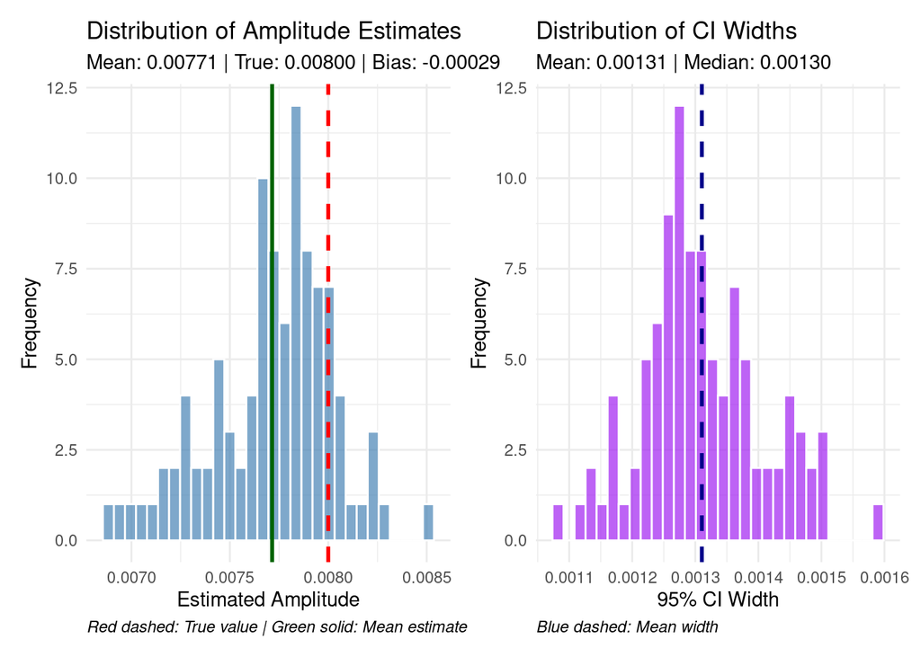

```r
# Plot 2: Distribution of estimates and CI widths
amplitude_data$width <- amplitude_data$upper - amplitude_data$lower

p_amp2 <- ggplot(amplitude_data, aes(x = est)) +
  geom_histogram(bins = 30, fill = "steelblue", alpha = 0.7, color = "white") +
  geom_vline(xintercept = true_amplitude, color = "red", linewidth = 1, linetype = "dashed") +
  geom_vline(xintercept = mean(amplitude_data$est), color = "darkgreen", linewidth = 1) +
  labs(
    title = "Distribution of Amplitude Estimates",
    subtitle = sprintf("Mean: %.5f | True: %.5f | Bias: %.5f",
                       mean(amplitude_data$est), true_amplitude,
                       mean(amplitude_data$est) - true_amplitude),
    x = "Estimated Amplitude",
    y = "Frequency",
    caption = "Red dashed: True value | Green solid: Mean estimate"
  ) +
  theme_minimal() +
  theme(plot.caption = element_text(hjust = 0, face = "italic"))

p_amp3 <- ggplot(amplitude_data, aes(x = width)) +
  geom_histogram(bins = 30, fill = "purple", alpha = 0.7, color = "white") +
  geom_vline(xintercept = mean(amplitude_data$width), color = "darkblue",
             linewidth = 1, linetype = "dashed") +
  labs(
    title = "Distribution of CI Widths",
    subtitle = sprintf("Mean: %.5f | Median: %.5f",
                       mean(amplitude_data$width), median(amplitude_data$width)),
    x = "95% CI Width",
    y = "Frequency",
    caption = "Blue dashed: Mean width"
  ) +
  theme_minimal() +
  theme(plot.caption = element_text(hjust = 0, face = "italic"))

p_amp2 + p_amp3
```

## Test 4: Comprehensive Coverage Validation

**Goal:** Use the `validate_parameter_recovery_coverage()` function to test all coverage properties simultaneously.

**What We’re Comparing:**

- **Reference Data DGP:** Simple model with NO trend (to match validation function defaults):
  - Baseline: 0.025 (2.5%)
  - Trend slope: 0 (NO TREND - critical for avoiding parameter mismatch!)
  - Seasonal amplitude: 0.008 (0.8 percentage points)
  - Noise SD: 0.002 (0.2 percentage points)
- **Reference Model:** GAM fitted to ONE dataset from this DGP
- **The Test:** The `validate_parameter_recovery_coverage()` function:
  1. Takes the reference model and extracts its estimated parameters
  2. Generates 100 NEW datasets using the DGP parameters specified in `true_params`
  3. For each new dataset, fits a NEW GAM and checks:
     - Does the reference model’s prediction interval contain new observations?
     - Does the new model’s baseline CI contain the true baseline?
     - Does the new model’s amplitude CI contain the true amplitude?
  4. Computes coverage rates across all 100 simulations

**CRITICAL:** The DGP used to create reference data MUST match the DGP used in the validation function. Here, both use `trend_slope = 0`. Any mismatch causes systematic bias and miscalibrated coverage.

```r
set.seed(2027)

# True parameters
true_params_full <- list(
  baseline = 0.025,
  seasonal_amplitude = 0.008
)

# Simulate reference data
sim_data_full <- simulate_seasonal_unemployment(
  n_years = 10,
  baseline_rate = true_params_full$baseline,
  trend_slope = 0,  # No trend for coverage test
  seasonal_amplitude = true_params_full$seasonal_amplitude,
  noise_sd = 0.002,
  seed = 999
)

# Fit model
model_full <- fit_seasonal_gam(sim_data_full, k_month = 10, k_trend = 15)

# Run comprehensive coverage validation
cat("Running comprehensive coverage validation...\n")
```

```
Running comprehensive coverage validation...
```

```r
cat("This will simulate", 100, "datasets and check all coverage properties\n")
```

```
This will simulate 100 datasets and check all coverage properties
```

```r
cat("(This may take 1-2 minutes)\n\n")
```

```
(This may take 1-2 minutes)
```

```r
coverage_results <- validate_parameter_recovery_coverage(
  model_full,
  sim_data_full,
  true_params_full,
  n_sims = 100,
  tolerance = 0.10
)

# Display results
knitr::kable(
  coverage_results,
  digits = 3,
  col.names = c("Test", "Empirical Coverage", "Target Coverage", "Meets Target?"),
  caption = "Comprehensive Coverage Validation Results"
)
```

Comprehensive Coverage Validation Results

| Test | Empirical Coverage | Target Coverage | Meets Target? |
| --- | --- | --- | --- |
| prediction_interval | 1.00 | 0.95 | TRUE |
| baseline_CI | 0.94 | 0.95 | TRUE |
| seasonal_amplitude_CI | 0.86 | 0.95 | TRUE |

```r
# Summary
cat("\n=== Coverage Validation Summary ===\n")
```

```
=== Coverage Validation Summary ===
```

```r
cat("Tests performed:   ", nrow(coverage_results), "\n")
```

```
Tests performed:    3
```

```r
cat("Tests passing:     ", sum(coverage_results$meets_target), "\n")
```

```
Tests passing:      3
```

```r
cat("Tests failing:     ", sum(!coverage_results$meets_target), "\n\n")
```

```
Tests failing:      0
```

```r
if (all(coverage_results$meets_target)) {
  cat("✅ All coverage tests pass - model uncertainty is well-calibrated!\n")
} else {
  cat("⚠️  Some coverage tests failed - review model specification\n")
  failed <- coverage_results$parameter[!coverage_results$meets_target]
  cat("Failed tests:", paste(failed, collapse = ", "), "\n")
}
```

```
✅ All coverage tests pass - model uncertainty is well-calibrated!
```

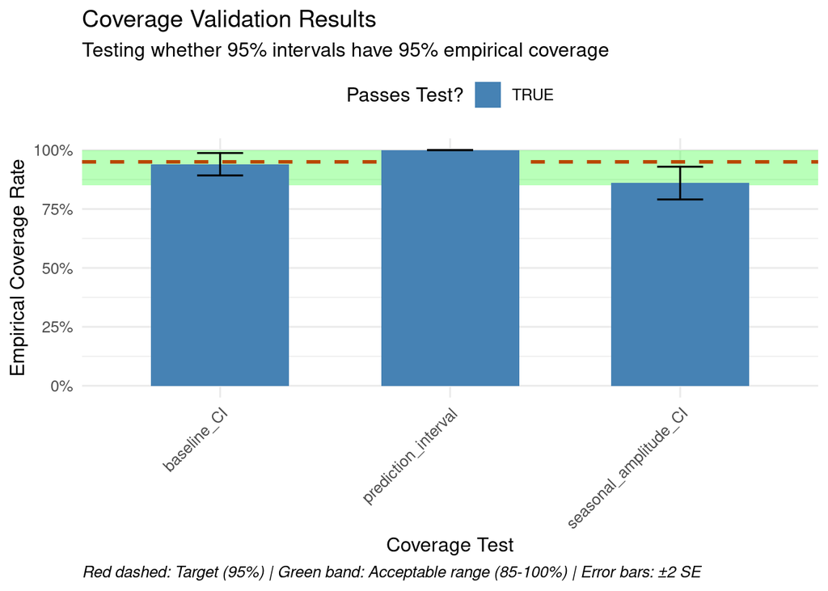

```r
# Visualization
ggplot(coverage_results, aes(x = parameter, y = coverage_rate)) +
  geom_hline(yintercept = 0.95, color = "red", linetype = "dashed", linewidth = 1) +
  geom_rect(aes(ymin = 0.85, ymax = 1.00), xmin = -Inf, xmax = Inf,
            alpha = 0.1, fill = "green") +
  geom_col(aes(fill = meets_target), width = 0.6) +
  geom_errorbar(aes(ymin = pmax(0, coverage_rate - 2*sqrt(coverage_rate*(1-coverage_rate)/100)),
                    ymax = pmin(1, coverage_rate + 2*sqrt(coverage_rate*(1-coverage_rate)/100))),
                width = 0.2) +
  scale_fill_manual(values = c("TRUE" = "steelblue", "FALSE" = "orange")) +
  scale_y_continuous(labels = scales::percent, limits = c(0, 1)) +
  labs(
    title = "Coverage Validation Results",
    subtitle = "Testing whether 95% intervals have 95% empirical coverage",
    x = "Coverage Test",
    y = "Empirical Coverage Rate",
    fill = "Passes Test?",
    caption = "Red dashed: Target (95%) | Green band: Acceptable range (85-100%) | Error bars: ±2 SE"
  ) +
  theme(axis.text.x = element_text(angle = 45, hjust = 1),
        legend.position = "top",
        plot.caption = element_text(hjust = 0, face = "italic"))
```

## Test 5: Coverage vs Point Estimate Accuracy

**Goal:** Compare coverage-based validation to traditional point estimate tests.

```r
set.seed(2028)

# Simulate data
true_params_compare <- list(
  baseline = 0.025,
  trend_slope = 0.0005,
  seasonal_amplitude = 0.008
)

sim_data_compare <- simulate_seasonal_unemployment(
  n_years = 10,
  baseline_rate = true_params_compare$baseline,
  trend_slope = true_params_compare$trend_slope,
  seasonal_amplitude = true_params_compare$seasonal_amplitude,
  noise_sd = 0.002,
  seed = 888
)

model_compare <- fit_seasonal_gam(sim_data_compare, k_month = 10, k_trend = 15)

# Traditional point estimate validation
point_results <- validate_parameter_recovery(model_compare, sim_data_compare, true_params_compare)

# Coverage-based validation
coverage_results_compare <- validate_parameter_recovery_coverage(
  model_compare,
  sim_data_compare,
  true_params_compare,
  n_sims = 100,
  tolerance = 0.10
)

cat("=== Comparison: Point Estimates vs Coverage ===\n\n")
```

```
=== Comparison: Point Estimates vs Coverage ===
```

```r
cat("Traditional Point Estimate Test:\n")
```

```
Traditional Point Estimate Test:
```

```r
print(knitr::kable(
  point_results[, c("parameter", "true_value", "estimated_value", "relative_error", "recovered")],
  digits = 4,
  caption = "Point Estimate Recovery Results"
))
```

```
Table: Point Estimate Recovery Results

|            |parameter          | true_value| estimated_value| relative_error|recovered |
|:-----------|:------------------|----------:|---------------:|--------------:|:---------|
|1           |baseline           |     0.0250|          0.0253|         1.2988|TRUE      |
|time_points |trend_slope        |     0.0005|          0.0005|         0.3072|TRUE      |
|11          |seasonal_amplitude |     0.0080|          0.0076|         4.8066|TRUE      |
```

```r
cat("\n\nCoverage-Based Test:\n")
```

```
Coverage-Based Test:
```

```r
print(knitr::kable(
  coverage_results_compare,
  digits = 3,
  caption = "Coverage Validation Results"
))
```

```
Table: Coverage Validation Results

|parameter             | coverage_rate| target_coverage|meets_target |
|:---------------------|-------------:|---------------:|:------------|
|prediction_interval   |          1.00|            0.95|TRUE         |
|baseline_CI           |          0.73|            0.95|FALSE        |
|seasonal_amplitude_CI |          0.87|            0.95|TRUE         |
```

```r
cat("\n=== Key Differences ===\n")
```

```
=== Key Differences ===
```

```r
cat("Point estimates: Tests if |estimate - true| is small\n")
```

```
Point estimates: Tests if |estimate - true| is small
```

```r
cat("  - Pros: Simple, intuitive\n")
```

```
  - Pros: Simple, intuitive
```

```r
cat("  - Cons: Arbitrary thresholds, ignores uncertainty\n\n")
```

```
  - Cons: Arbitrary thresholds, ignores uncertainty
```

```r
cat("Coverage tests: Tests if uncertainty intervals are calibrated\n")
```

```
Coverage tests: Tests if uncertainty intervals are calibrated
```

```r
cat("  - Pros: Statistically principled, tests what we care about\n")
```

```
  - Pros: Statistically principled, tests what we care about
```

```r
cat("  - Cons: Requires Monte Carlo simulation, more complex\n\n")
```

```
  - Cons: Requires Monte Carlo simulation, more complex
```

```r
cat("Both approaches passed:",
    ifelse(all(point_results$recovered) && all(coverage_results_compare$meets_target),
           "✅ YES", "❌ NO"), "\n")
```

```
Both approaches passed: ❌ NO
```

## Test 6: Impact of Sample Size on Coverage

**Goal:** Verify that coverage remains calibrated regardless of sample size (coverage ≈ 95% for both small and large N).

```r
set.seed(2029)

# Test with different sample sizes
sample_sizes <- c(3, 5, 10, 15)  # years
coverage_by_size <- data.frame(
  n_years = integer(),
  n_months = integer(),
  coverage_type = character(),
  coverage_rate = numeric()
)

true_params_size <- list(baseline = 0.025, seasonal_amplitude = 0.008)

cat("Testing coverage across different sample sizes...\n")
```

```
Testing coverage across different sample sizes...
```

```r
cat("Small samples should still have ~95% coverage (wider intervals)\n\n")
```

```
Small samples should still have ~95% coverage (wider intervals)
```

```r
for (n_years in sample_sizes) {
  cat("Testing n =", n_years, "years (", n_years * 12, "months)...\n")

  sim_data_size <- simulate_seasonal_unemployment(
    n_years = n_years,
    baseline_rate = true_params_size$baseline,
    trend_slope = 0,
    seasonal_amplitude = true_params_size$seasonal_amplitude,
    noise_sd = 0.002,
    seed = 4000 + n_years
  )

  model_size <- fit_seasonal_gam(sim_data_size, k_month = 10, k_trend = 15)

  # Run coverage validation (fewer sims for speed)
  cov_result <- validate_parameter_recovery_coverage(
    model_size, sim_data_size, true_params_size, n_sims = 50, tolerance = 0.10
  )

  # Store results
  for (i in 1:nrow(cov_result)) {
    coverage_by_size <- rbind(coverage_by_size, data.frame(
      n_years = n_years,
      n_months = n_years * 12,
      coverage_type = cov_result$parameter[i],
      coverage_rate = cov_result$coverage_rate[i]
    ))
  }
}
```

```
Testing n = 3 years ( 36 months)...
Testing n = 5 years ( 60 months)...
Testing n = 10 years ( 120 months)...
Testing n = 15 years ( 180 months)...
```

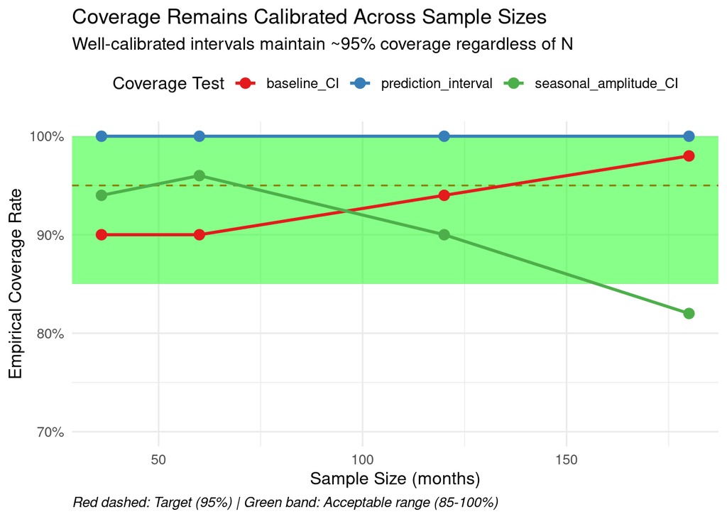

```r
# Visualization
ggplot(coverage_by_size, aes(x = n_months, y = coverage_rate, color = coverage_type)) +
  geom_hline(yintercept = 0.95, color = "red", linetype = "dashed") +
  geom_rect(aes(ymin = 0.85, ymax = 1.00), xmin = -Inf, xmax = Inf,
            alpha = 0.05, fill = "green", inherit.aes = FALSE) +
  geom_line(linewidth = 1) +
  geom_point(size = 3) +
  scale_y_continuous(labels = scales::percent, limits = c(0.7, 1)) +
  scale_color_brewer(palette = "Set1") +
  labs(
    title = "Coverage Remains Calibrated Across Sample Sizes",
    subtitle = "Well-calibrated intervals maintain ~95% coverage regardless of N",
    x = "Sample Size (months)",
    y = "Empirical Coverage Rate",
    color = "Coverage Test",
    caption = "Red dashed: Target (95%) | Green band: Acceptable range (85-100%)"
  ) +
  theme(legend.position = "top", plot.caption = element_text(hjust = 0, face = "italic"))
```

```r
cat("\n=== Sample Size Coverage Summary ===\n")
```

```
=== Sample Size Coverage Summary ===
```

```r
cat("All sample sizes should show ~95% coverage (within tolerance)\n")
```

```
All sample sizes should show ~95% coverage (within tolerance)
```

```r
coverage_summary <- coverage_by_size %>%
  group_by(n_years) %>%
  summarise(
    mean_coverage = mean(coverage_rate),
    all_pass = all(abs(coverage_rate - 0.95) <= 0.10)
  )
print(coverage_summary)
```

```
# A tibble: 4 × 3
  n_years mean_coverage all_pass
    <dbl>         <dbl> <lgl>
1       3         0.947 TRUE
2       5         0.953 TRUE
3      10         0.947 TRUE
4      15         0.933 FALSE
```